# Seattle Airbnb Open Data will be analyzed based on the CRISP-DM

**The subprocesses of the CRISP-DM "cross industry standard process for data science" are written below.**

1. Business Understanding; developing business Understanding
2. Data Understanding; developing Data Understanding
3. Prepare Data; prepare your data to be analyzed
4. Data Modeling; modeling the data
5. Evaluate the Results; evaluating the result to answer your questions
6. Deploy; deploying changes based on the results of your analysis

# 1. Business Understanding

**What is the seasonal pattern of Airbnb in Seattle?**

**What kinds of Airbnb homes are popular?**

**What are the most of features or the most components in the data?** Use sklearn's PCA class to apply principal component analysis on the data, thus finding the vectors of maximal variance in the data.

### import necessary Library

```python
import numpy as np
import pandas as pd
import matplotlib.pyplot as plt
import matplotlib
import seaborn as sns
from pandas.tseries.holiday import USFederalHolidayCalendar as calendar #To check holidays in the U.S
from matplotlib.dates import YearLocator, MonthLocator, DateFormatter, WeekdayLocator, DayLocator
%matplotlib inline
import time
import re
from datetime import datetime
import matplotlib.dates as mdates
from scipy.ndimage.filters import gaussian_filter1d
from sklearn import preprocessing as p
from sklearn.decomposition import PCA
import operator
import pprint
```

# 2_understanding the data

**let us load the csv files**

```python
df_listing = pd.read_csv('./listings.csv')
df_calendar = pd.read_csv('./calendar.csv')
df_reviews = pd.read_csv('./reviews.csv')
```

```python
df_listing.head()
```

|  | id | listing_url | scrape_id | last_scraped | name | summary | space | description | experiences_offered | neighborhood_overview | ... | review_scores_value | requires_license | license | jurisdiction_names | instant_bookable | cancellation_policy | require_guest_profile_picture | require_guest_phone_verification | calculated_host_listings_count | reviews_per_month |
| --- | --- | --- | --- | --- | --- | --- | --- | --- | --- | --- | --- | --- | --- | --- | --- | --- | --- | --- | --- | --- | --- |
| 0 | 241032 | https://www.airbnb.com/rooms/241032 | 20160104002432 | 2016-01-04 | Stylish Queen Anne Apartment | NaN | Make your self at home in this charming one-be... | Make your self at home in this charming one-be... | none | NaN | ... | 10.0 | f | NaN | WASHINGTON | f | moderate | f | f | 2 | 4.07 |
| 1 | 953595 | https://www.airbnb.com/rooms/953595 | 20160104002432 | 2016-01-04 | Bright & Airy Queen Anne Apartment | Chemically sensitive? We've removed the irrita... | Beautiful, hypoallergenic apartment in an extr... | Chemically sensitive? We've removed the irrita... | none | Queen Anne is a wonderful, truly functional vi... | ... | 10.0 | f | NaN | WASHINGTON | f | strict | t | t | 6 | 1.48 |
| 2 | 3308979 | https://www.airbnb.com/rooms/3308979 | 20160104002432 | 2016-01-04 | New Modern House-Amazing water view | New modern house built in 2013. Spectacular s... | Our house is modern, light and fresh with a wa... | New modern house built in 2013. Spectacular s... | none | Upper Queen Anne is a charming neighborhood fu... | ... | 10.0 | f | NaN | WASHINGTON | f | strict | f | f | 2 | 1.15 |
| 3 | 7421966 | https://www.airbnb.com/rooms/7421966 | 20160104002432 | 2016-01-04 | Queen Anne Chateau | A charming apartment that sits atop Queen Anne... | NaN | A charming apartment that sits atop Queen Anne... | none | NaN | ... | NaN | f | NaN | WASHINGTON | f | flexible | f | f | 1 | NaN |
| 4 | 278830 | https://www.airbnb.com/rooms/278830 | 20160104002432 | 2016-01-04 | Charming craftsman 3 bdm house | Cozy family craftman house in beautiful neighb... | Cozy family craftman house in beautiful neighb... | Cozy family craftman house in beautiful neighb... | none | We are in the beautiful neighborhood of Queen ... | ... | 9.0 | f | NaN | WASHINGTON | f | strict | f | f | 1 | 0.89 |

5 rows × 92 columns

```python
df_listing.info()
```

```
<class 'pandas.core.frame.DataFrame'>
RangeIndex: 3818 entries, 0 to 3817
Data columns (total 92 columns):
id                                  3818 non-null int64
listing_url                         3818 non-null object
scrape_id                           3818 non-null int64
last_scraped                        3818 non-null object
name                                3818 non-null object
summary                             3641 non-null object
space                               3249 non-null object
description                         3818 non-null object
experiences_offered                 3818 non-null object
neighborhood_overview               2786 non-null object
notes                               2212 non-null object
transit                             2884 non-null object
thumbnail_url                       3498 non-null object
medium_url                          3498 non-null object
picture_url                         3818 non-null object
xl_picture_url                      3498 non-null object
host_id                             3818 non-null int64
host_url                            3818 non-null object
host_name                           3816 non-null object
host_since                          3816 non-null object
host_location                       3810 non-null object
host_about                          2959 non-null object
host_response_time                  3295 non-null object
host_response_rate                  3295 non-null object
host_acceptance_rate                3045 non-null object
host_is_superhost                   3816 non-null object
host_thumbnail_url                  3816 non-null object
host_picture_url                    3816 non-null object
host_neighbourhood                  3518 non-null object
host_listings_count                 3816 non-null float64
host_total_listings_count           3816 non-null float64
host_verifications                  3818 non-null object
host_has_profile_pic                3816 non-null object
host_identity_verified              3816 non-null object
street                              3818 non-null object
neighbourhood                       3402 non-null object
neighbourhood_cleansed              3818 non-null object
```

[output cut: 42 more lines]

```
review_scores_checkin               3160 non-null float64
review_scores_communication         3167 non-null float64
review_scores_location              3163 non-null float64
review_scores_value                 3162 non-null float64
requires_license                    3818 non-null object
license                             0 non-null float64
jurisdiction_names                  3818 non-null object
instant_bookable                    3818 non-null object
cancellation_policy                 3818 non-null object
require_guest_profile_picture       3818 non-null object
require_guest_phone_verification    3818 non-null object
calculated_host_listings_count      3818 non-null int64
reviews_per_month                   3191 non-null float64
dtypes: float64(17), int64(13), object(62)
memory usage: 2.7+ MB
```

```python
df_reviews.head()
```

|  | listing_id | id | date | reviewer_id | reviewer_name | comments |
| --- | --- | --- | --- | --- | --- | --- |
| 0 | 7202016 | 38917982 | 2015-07-19 | 28943674 | Bianca | Cute and cozy place. Perfect location to every... |
| 1 | 7202016 | 39087409 | 2015-07-20 | 32440555 | Frank | Kelly has a great room in a very central locat... |
| 2 | 7202016 | 39820030 | 2015-07-26 | 37722850 | Ian | Very spacious apartment, and in a great neighb... |
| 3 | 7202016 | 40813543 | 2015-08-02 | 33671805 | George | Close to Seattle Center and all it has to offe... |
| 4 | 7202016 | 41986501 | 2015-08-10 | 34959538 | Ming | Kelly was a great host and very accommodating ... |

```python
df_reviews.info()
```

```
<class 'pandas.core.frame.DataFrame'>
RangeIndex: 84849 entries, 0 to 84848
Data columns (total 6 columns):
listing_id       84849 non-null int64
id               84849 non-null int64
date             84849 non-null object
reviewer_id      84849 non-null int64
reviewer_name    84849 non-null object
comments         84831 non-null object
dtypes: int64(3), object(3)
memory usage: 3.9+ MB
```

```python
df_calendar.head()
```

|  | listing_id | date | available | price |
| --- | --- | --- | --- | --- |
| 0 | 241032 | 2016-01-04 | t | $85.00 |
| 1 | 241032 | 2016-01-05 | t | $85.00 |
| 2 | 241032 | 2016-01-06 | f | NaN |
| 3 | 241032 | 2016-01-07 | f | NaN |
| 4 | 241032 | 2016-01-08 | f | NaN |

```python
df_calendar.info()
```

```
<class 'pandas.core.frame.DataFrame'>
RangeIndex: 1393570 entries, 0 to 1393569
Data columns (total 4 columns):
listing_id    1393570 non-null int64
date          1393570 non-null object
available     1393570 non-null object
price         934542 non-null object
dtypes: int64(1), object(3)
memory usage: 42.5+ MB
```

# 3_Prepare the data

### 1_Modify df_calendar

```python
df_calendar.price
```

```
0          $85.00
1          $85.00
2             NaN
3             NaN
4             NaN
5             NaN
6             NaN
7             NaN
8             NaN
9          $85.00
10         $85.00
11            NaN
12            NaN
13            NaN
14         $85.00
```

[output cut: 47 more lines]

### For price column

**First we need to remove '$' ,'%' and convert them to float to easy analysis.**

```python
df_calendar['price'] = df_calendar['price'].map(lambda price: float(price[1:].replace(',', '')), na_action='ignore')
df_calendar.price
```

```
0          85.0
1          85.0
2           NaN
3           NaN
4           NaN
5           NaN
6           NaN
7           NaN
8           NaN
9          85.0
10         85.0
11          NaN
12          NaN
13          NaN
14         85.0
```

[output cut: 47 more lines]

### Second filling missing Value in price column

# Hint

**To run a machine learning algorithm, you can't have missing value in your dataset. you really only have two option:**

1- you can delet them

2- you can fill in the missing value using mean or forward fill or backward filling espiciall for ordered or time seires data if the data is ordered by time

# DataFrame.fillna(value=None, method=None, axis=None, inplace=False, limit=None, downcast=None, **kwargs)

we can get mor information from [pandas.DataFrame.fillna](https://pandas.pydata.org/pandas-docs/version/0.22/generated/pandas.DataFrame.fillna.html#)

```python
#df_calendar.price_new = df_calendar.price.transform(lambda x: x.fillna(x.mean()))
#or

df_calendar.price_new = df_calendar.price.fillna(method='ffill')
#df_calendar.price_new = df_calendar.price.fillna(method='bfill')
df_calendar.price_new
```

```
0          85.0
1          85.0
2          85.0
3          85.0
4          85.0
5          85.0
6          85.0
7          85.0
8          85.0
9          85.0
10         85.0
11         85.0
12         85.0
13         85.0
14         85.0
```

[output cut: 47 more lines]

**we can update the old column with the new using** [DataFrame.update](https://pandas.pydata.org/pandas-docs/stable/reference/api/pandas.DataFrame.update.html)

```python
df_calendar.update(df_calendar.price_new)
df_calendar.head()
```

|  | listing_id | date | available | price |
| --- | --- | --- | --- | --- |
| 0 | 241032 | 2016-01-04 | t | 85.0 |
| 1 | 241032 | 2016-01-05 | t | 85.0 |
| 2 | 241032 | 2016-01-06 | f | 85.0 |
| 3 | 241032 | 2016-01-07 | f | 85.0 |
| 4 | 241032 | 2016-01-08 | f | 85.0 |

```python
df_calendar.price.isnull().sum()
```

```
0
```

```python
df_calendar.price.describe()
```

```
count    1.393570e+06
mean     1.360387e+02
std      1.018518e+02
min      1.000000e+01
25%      7.500000e+01
50%      1.050000e+02
75%      1.600000e+02
max      1.650000e+03
Name: price, dtype: float64
```

### For date column

**creates 'year', 'month', 'day', 'weekday', and 'week_number' columns from 'date' coulmn of df_calendar**

```python
# Modify df_calendar for future work
# Special event : marathon, new academic season

# Split date column into year, month,day, weekday columns
# The day of the week with Monday=0, Sunday=6
# Set the range of weekends from Friday to Sunday
df_calendar['year'] = pd.DatetimeIndex(df_calendar['date']).year
df_calendar['month'] = pd.DatetimeIndex(df_calendar['date']).month
df_calendar['day'] = pd.DatetimeIndex(df_calendar['date']).day
df_calendar['weekday'] = pd.DatetimeIndex(df_calendar['date']).weekday
df_calendar['week_number'] = pd.DatetimeIndex(df_calendar['date']).week

df_calendar.head()
```

|  | listing_id | date | available | price | year | month | day | weekday | week_number |
| --- | --- | --- | --- | --- | --- | --- | --- | --- | --- |
| 0 | 241032 | 2016-01-04 | t | 85.0 | 2016 | 1 | 4 | 0 | 1 |
| 1 | 241032 | 2016-01-05 | t | 85.0 | 2016 | 1 | 5 | 1 | 1 |
| 2 | 241032 | 2016-01-06 | f | 85.0 | 2016 | 1 | 6 | 2 | 1 |
| 3 | 241032 | 2016-01-07 | f | 85.0 | 2016 | 1 | 7 | 3 | 1 |
| 4 | 241032 | 2016-01-08 | f | 85.0 | 2016 | 1 | 8 | 4 | 1 |

### For available column

**Convert category values to just numbers 0 or 1**

```python
df_calendar.available.value_counts()
```

```
t    934542
f    459028
Name: available, dtype: int64
```

```python
# convert 'available' into binary
#df_calendar['available'] = df_calendar['available'].map(lambda available: 1 if available == 't' else 0)
#or
df_calendar['available'].replace(['t','f'], [1,0], inplace=True)
```

```python
df_calendar.available.value_counts()
```

```
1    934542
0    459028
Name: available, dtype: int64
```

```python
df_calendar.head()
```

|  | listing_id | date | available | price | year | month | day | weekday | week_number |
| --- | --- | --- | --- | --- | --- | --- | --- | --- | --- |
| 0 | 241032 | 2016-01-04 | 1 | 85.0 | 2016 | 1 | 4 | 0 | 1 |
| 1 | 241032 | 2016-01-05 | 1 | 85.0 | 2016 | 1 | 5 | 1 | 1 |
| 2 | 241032 | 2016-01-06 | 0 | 85.0 | 2016 | 1 | 6 | 2 | 1 |
| 3 | 241032 | 2016-01-07 | 0 | 85.0 | 2016 | 1 | 7 | 3 | 1 |
| 4 | 241032 | 2016-01-08 | 0 | 85.0 | 2016 | 1 | 8 | 4 | 1 |

### 2_Modify df_listing

```python
df_listing.columns
```

```
Index(['id', 'listing_url', 'scrape_id', 'last_scraped', 'name', 'summary',
       'space', 'description', 'experiences_offered', 'neighborhood_overview',
       'notes', 'transit', 'thumbnail_url', 'medium_url', 'picture_url',
       'xl_picture_url', 'host_id', 'host_url', 'host_name', 'host_since',
       'host_location', 'host_about', 'host_response_time',
       'host_response_rate', 'host_acceptance_rate', 'host_is_superhost',
       'host_thumbnail_url', 'host_picture_url', 'host_neighbourhood',
       'host_listings_count', 'host_total_listings_count',
       'host_verifications', 'host_has_profile_pic', 'host_identity_verified',
       'street', 'neighbourhood', 'neighbourhood_cleansed',
       'neighbourhood_group_cleansed', 'city', 'state', 'zipcode', 'market',
       'smart_location', 'country_code', 'country', 'latitude', 'longitude',
       'is_location_exact', 'property_type', 'room_type', 'accommodates',
       'bathrooms', 'bedrooms', 'beds', 'bed_type', 'amenities', 'square_feet',
       'price', 'weekly_price', 'monthly_price', 'security_deposit',
       'cleaning_fee', 'guests_included', 'extra_people', 'minimum_nights',
       'maximum_nights', 'calendar_updated', 'has_availability',
       'availability_30', 'availability_60', 'availability_90',
       'availability_365', 'calendar_last_scraped', 'number_of_reviews',
       'first_review', 'last_review', 'review_scores_rating',
       'review_scores_accuracy', 'review_scores_cleanliness',
       'review_scores_checkin', 'review_scores_communication',
       'review_scores_location', 'review_scores_value', 'requires_license',
       'license', 'jurisdiction_names', 'instant_bookable',
       'cancellation_policy', 'require_guest_profile_picture',
       'require_guest_phone_verification', 'calculated_host_listings_count',
       'reviews_per_month'],
      dtype='object')
```

### finding the columns consisting of missing values over 50%

**To run a machine learning algorithm, you can't have missing value in your dataset. you really only have two option:**

1- you can delet them

2- you can fill in the missing value using mean or forward fill or backward filling espiciall for ordered or time seires data if the data is ordered by time

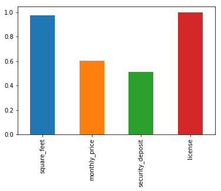

```python
df_missing = df_listing.isna().mean()
df_missing[df_missing>0.5].plot.bar()
```

**i assume that columns with more than 50% missing values are outliers, so extract them and drop them from the data frame, so I am going to extract the columns with more than 50% missing values Out of.**

```python
len(df_listing.columns)
```

```
92
```

### droped the columns consisting of missing values over 50%

```python
#df_listing.drop('square_feet', axis=1, inplace=True)
#or
df_listing.drop(['square_feet', 'monthly_price', 'security_deposit', 'license' ], axis=1, inplace=True)
```

```python
len(df_listing.columns)
```

```
88
```

```python
df_listing.head()
```

|  | id | listing_url | scrape_id | last_scraped | name | summary | space | description | experiences_offered | neighborhood_overview | ... | review_scores_location | review_scores_value | requires_license | jurisdiction_names | instant_bookable | cancellation_policy | require_guest_profile_picture | require_guest_phone_verification | calculated_host_listings_count | reviews_per_month |
| --- | --- | --- | --- | --- | --- | --- | --- | --- | --- | --- | --- | --- | --- | --- | --- | --- | --- | --- | --- | --- | --- |
| 0 | 241032 | https://www.airbnb.com/rooms/241032 | 20160104002432 | 2016-01-04 | Stylish Queen Anne Apartment | NaN | Make your self at home in this charming one-be... | Make your self at home in this charming one-be... | none | NaN | ... | 9.0 | 10.0 | f | WASHINGTON | f | moderate | f | f | 2 | 4.07 |
| 1 | 953595 | https://www.airbnb.com/rooms/953595 | 20160104002432 | 2016-01-04 | Bright & Airy Queen Anne Apartment | Chemically sensitive? We've removed the irrita... | Beautiful, hypoallergenic apartment in an extr... | Chemically sensitive? We've removed the irrita... | none | Queen Anne is a wonderful, truly functional vi... | ... | 10.0 | 10.0 | f | WASHINGTON | f | strict | t | t | 6 | 1.48 |
| 2 | 3308979 | https://www.airbnb.com/rooms/3308979 | 20160104002432 | 2016-01-04 | New Modern House-Amazing water view | New modern house built in 2013. Spectacular s... | Our house is modern, light and fresh with a wa... | New modern house built in 2013. Spectacular s... | none | Upper Queen Anne is a charming neighborhood fu... | ... | 10.0 | 10.0 | f | WASHINGTON | f | strict | f | f | 2 | 1.15 |
| 3 | 7421966 | https://www.airbnb.com/rooms/7421966 | 20160104002432 | 2016-01-04 | Queen Anne Chateau | A charming apartment that sits atop Queen Anne... | NaN | A charming apartment that sits atop Queen Anne... | none | NaN | ... | NaN | NaN | f | WASHINGTON | f | flexible | f | f | 1 | NaN |
| 4 | 278830 | https://www.airbnb.com/rooms/278830 | 20160104002432 | 2016-01-04 | Charming craftsman 3 bdm house | Cozy family craftman house in beautiful neighb... | Cozy family craftman house in beautiful neighb... | Cozy family craftman house in beautiful neighb... | none | We are in the beautiful neighborhood of Queen ... | ... | 9.0 | 9.0 | f | WASHINGTON | f | strict | f | f | 1 | 0.89 |

5 rows × 88 columns

```python
#url_regex = 'http[s]?://(?:[a-zA-Z]|[0-9]|[$-_@.&+]|[!*\(\),]|(?:%[0-9a-fA-F][0-9a-fA-F]))+'
```

### finding the columns consisting urls as the url's directs to the home page wich is not very useful.

```python
row = df_listing.iloc[0,:]
row
```

```
id                                                                             241032
listing_url                                       https://www.airbnb.com/rooms/241032
scrape_id                                                              20160104002432
last_scraped                                                               2016-01-04
name                                                     Stylish Queen Anne Apartment
summary                                                                           NaN
space                               Make your self at home in this charming one-be...
description                         Make your self at home in this charming one-be...
experiences_offered                                                              none
neighborhood_overview                                                             NaN
notes                                                                             NaN
transit                                                                           NaN
thumbnail_url                                                                     NaN
medium_url                                                                        NaN
picture_url                         https://a1.muscache.com/ac/pictures/67560560/c...
xl_picture_url                                                                    NaN
host_id                                                                        956883
host_url                                     https://www.airbnb.com/users/show/956883
host_name                                                                       Maija
host_since                                                                 2011-08-11
host_location                                      Seattle, Washington, United States
host_about                          I am an artist, interior designer, and run a s...
host_response_time                                                 within a few hours
host_response_rate                                                                96%
host_acceptance_rate                                                             100%
host_is_superhost                                                                   f
host_thumbnail_url                  https://a0.muscache.com/ac/users/956883/profil...
host_picture_url                    https://a0.muscache.com/ac/users/956883/profil...
host_neighbourhood                                                         Queen Anne
host_listings_count                                                                 3
                                                          ...
cleaning_fee                                                                      NaN
guests_included                                                                     2
extra_people                                                                    $5.00
minimum_nights                                                                      1
maximum_nights                                                                    365
calendar_updated                                                          4 weeks ago
has_availability                                                                    t
availability_30                                                                    14
availability_60                                                                    41
availability_90                                                                    71
availability_365                                                                  346
calendar_last_scraped                                                      2016-01-04
number_of_reviews                                                                 207
first_review                                                               2011-11-01
last_review                                                                2016-01-02
review_scores_rating                                                               95
review_scores_accuracy                                                             10
review_scores_cleanliness                                                          10
review_scores_checkin                                                              10
review_scores_communication                                                        10
review_scores_location                                                              9
review_scores_value                                                                10
requires_license                                                                    f
jurisdiction_names                                                         WASHINGTON
instant_bookable                                                                    f
cancellation_policy                                                          moderate
require_guest_profile_picture                                                       f
require_guest_phone_verification                                                    f
calculated_host_listings_count                                                      2
reviews_per_month                                                                4.07
Name: 0, Length: 88, dtype: object
```

### droped the columns consisting urls as the url's

```python
df_listing.drop(['host_picture_url', 'host_thumbnail_url', 'host_url', 'picture_url', 'listing_url'], axis=1, inplace=True)
```

```python
#check
row2 = df_listing.iloc[1,:]
row2
```

```
id                                                                             953595
scrape_id                                                              20160104002432
last_scraped                                                               2016-01-04
name                                               Bright & Airy Queen Anne Apartment
summary                             Chemically sensitive? We've removed the irrita...
space                               Beautiful, hypoallergenic apartment in an extr...
description                         Chemically sensitive? We've removed the irrita...
experiences_offered                                                              none
neighborhood_overview               Queen Anne is a wonderful, truly functional vi...
notes                               What's up with the free pillows?  Our home was...
transit                             Convenient bus stops are just down the block, ...
thumbnail_url                       https://a0.muscache.com/ac/pictures/14409893/f...
medium_url                          https://a0.muscache.com/im/pictures/14409893/f...
xl_picture_url                      https://a0.muscache.com/ac/pictures/14409893/f...
host_id                                                                       5177328
host_name                                                                      Andrea
host_since                                                                 2013-02-21
host_location                                      Seattle, Washington, United States
host_about                          Living east coast/left coast/overseas.  Time i...
host_response_time                                                     within an hour
host_response_rate                                                                98%
host_acceptance_rate                                                             100%
host_is_superhost                                                                   t
host_neighbourhood                                                         Queen Anne
host_listings_count                                                                 6
host_total_listings_count                                                           6
host_verifications                  ['email', 'phone', 'facebook', 'linkedin', 're...
host_has_profile_pic                                                                t
host_identity_verified                                                              t
street                              7th Avenue West, Seattle, WA 98119, United States
                                                          ...
cleaning_fee                                                                   $40.00
guests_included                                                                     1
extra_people                                                                    $0.00
minimum_nights                                                                      2
maximum_nights                                                                     90
calendar_updated                                                                today
has_availability                                                                    t
availability_30                                                                    13
availability_60                                                                    13
availability_90                                                                    16
availability_365                                                                  291
calendar_last_scraped                                                      2016-01-04
number_of_reviews                                                                  43
first_review                                                               2013-08-19
last_review                                                                2015-12-29
review_scores_rating                                                               96
review_scores_accuracy                                                             10
review_scores_cleanliness                                                          10
review_scores_checkin                                                              10
review_scores_communication                                                        10
review_scores_location                                                             10
review_scores_value                                                                10
requires_license                                                                    f
jurisdiction_names                                                         WASHINGTON
instant_bookable                                                                    f
cancellation_policy                                                            strict
require_guest_profile_picture                                                       t
require_guest_phone_verification                                                    t
calculated_host_listings_count                                                      6
reviews_per_month                                                                1.48
Name: 1, Length: 83, dtype: object
```

```python
df_listing.drop(['xl_picture_url', 'medium_url','thumbnail_url'], axis=1, inplace=True)
```

```python
#check
row10 = df_listing.iloc[10,:]
row10
```

```
id                                                                             175576
scrape_id                                                              20160104002432
last_scraped                                                               2016-01-04
name                                              Private Apartment - Queen Anne Hill
summary                             Queen Anne Hill is a charming neighborhood wit...
space                               Be close to everything!  Queen Anne Hill is a ...
description                         Queen Anne Hill is a charming neighborhood wit...
experiences_offered                                                              none
neighborhood_overview               Queen Anne Hill is a wonderful and historic ar...
notes                               We will provide you with a Parking Pass to han...
transit                             The bus stop is just two blocks from our house...
host_id                                                                        239585
host_name                                                                Ray & Eileen
host_since                                                                 2010-09-19
host_location                                      Seattle, Washington, United States
host_about                          Eileen and Ray were born in Seattle just three...
host_response_time                                                 within a few hours
host_response_rate                                                               100%
host_acceptance_rate                                                             100%
host_is_superhost                                                                   t
host_neighbourhood                                                         Queen Anne
host_listings_count                                                                 1
host_total_listings_count                                                           1
host_verifications                               ['email', 'phone', 'reviews', 'kba']
host_has_profile_pic                                                                t
host_identity_verified                                                              t
street                                    1st Ave W, Seattle, WA 98119, United States
neighbourhood                                                              Queen Anne
neighbourhood_cleansed                                                West Queen Anne
neighbourhood_group_cleansed                                               Queen Anne
                                                          ...
cleaning_fee                                                                   $15.00
guests_included                                                                     2
extra_people                                                                   $15.00
minimum_nights                                                                      3
maximum_nights                                                                      7
calendar_updated                                                           a week ago
has_availability                                                                    t
availability_30                                                                     0
availability_60                                                                     0
availability_90                                                                     0
availability_365                                                                  153
calendar_last_scraped                                                      2016-01-04
number_of_reviews                                                                 181
first_review                                                               2011-07-21
last_review                                                                2015-11-25
review_scores_rating                                                               97
review_scores_accuracy                                                             10
review_scores_cleanliness                                                          10
review_scores_checkin                                                              10
review_scores_communication                                                        10
review_scores_location                                                             10
review_scores_value                                                                10
requires_license                                                                    f
jurisdiction_names                                                         WASHINGTON
instant_bookable                                                                    f
cancellation_policy                                                          moderate
require_guest_profile_picture                                                       t
require_guest_phone_verification                                                    f
calculated_host_listings_count                                                      1
reviews_per_month                                                                3.33
Name: 10, Length: 80, dtype: object
```

```python
len(df_listing.columns)
```

```
80
```

### Rmoving characters in "cleaning fee" and convert it to float to easy analysis.

```python
df_listing['cleaning_fee'] = df_listing.cleaning_fee.str.replace('$','').astype(float)
```

```python
df_listing.cleaning_fee
```

```
0         NaN
1        40.0
2       300.0
3         NaN
4       125.0
5        40.0
6         NaN
7        25.0
8         NaN
9        40.0
10       15.0
11      150.0
12       95.0
13       85.0
14      300.0
```

[output cut: 47 more lines]

### Rmoving characters in "host acceptance rate" convert it to float to easy analysis.

```python
df_listing['host_acceptance_rate'] = df_listing.host_acceptance_rate.str.replace('%','').astype(float)
```

```python
df_listing.host_acceptance_rate
```

```
0       100.0
1       100.0
2       100.0
3         NaN
4         NaN
5         NaN
6       100.0
7       100.0
8       100.0
9       100.0
10      100.0
11      100.0
12      100.0
13      100.0
14      100.0
```

[output cut: 47 more lines]

```python
df_listing_object= df_listing.select_dtypes(include=['object'])
df_listing_object.columns
```

```
Index(['last_scraped', 'name', 'summary', 'space', 'description',
       'experiences_offered', 'neighborhood_overview', 'notes', 'transit',
       'host_name', 'host_since', 'host_location', 'host_about',
       'host_response_time', 'host_response_rate', 'host_is_superhost',
       'host_neighbourhood', 'host_verifications', 'host_has_profile_pic',
       'host_identity_verified', 'street', 'neighbourhood',
       'neighbourhood_cleansed', 'neighbourhood_group_cleansed', 'city',
       'state', 'zipcode', 'market', 'smart_location', 'country_code',
       'country', 'is_location_exact', 'property_type', 'room_type',
       'bed_type', 'amenities', 'price', 'weekly_price', 'extra_people',
       'calendar_updated', 'has_availability', 'calendar_last_scraped',
       'first_review', 'last_review', 'requires_license', 'jurisdiction_names',
       'instant_bookable', 'cancellation_policy',
       'require_guest_profile_picture', 'require_guest_phone_verification'],
      dtype='object')
```

```python
df_listing_object.isnull().sum()
```

```
last_scraped                           0
name                                   0
summary                              177
space                                569
description                            0
experiences_offered                    0
neighborhood_overview               1032
notes                               1606
transit                              934
host_name                              2
host_since                             2
host_location                          8
host_about                           859
host_response_time                   523
host_response_rate                   523
host_is_superhost                      2
host_neighbourhood                   300
host_verifications                     0
host_has_profile_pic                   2
host_identity_verified                 2
street                                 0
neighbourhood                        416
neighbourhood_cleansed                 0
neighbourhood_group_cleansed           0
city                                   0
state                                  0
zipcode                                7
market                                 0
smart_location                         0
country_code                           0
country                                0
is_location_exact                      0
property_type                          1
room_type                              0
bed_type                               0
amenities                              0
price                                  0
weekly_price                        1809
extra_people                           0
calendar_updated                       0
has_availability                       0
calendar_last_scraped                  0
first_review                         627
last_review                          627
requires_license                       0
jurisdiction_names                     0
instant_bookable                       0
cancellation_policy                    0
require_guest_profile_picture          0
require_guest_phone_verification       0
dtype: int64
```

```python
lis = ['summary', 'space', 'neighborhood_overview', 'notes', 'transit','host_name', 'host_since', 'host_location', 'host_about','host_response_time', 'host_response_rate','host_is_superhost', 'host_neighbourhood','host_has_profile_pic', 'host_identity_verified','neighbourhood','zipcode','property_type','weekly_price', 'first_review', 'last_review']


for i in lis:

    df_listing_object[i].fillna(df_listing_object[i].mode()[0], inplace=True)
```

```python
df_listing_object.isnull().sum()
```

```
last_scraped                        0
name                                0
summary                             0
space                               0
description                         0
experiences_offered                 0
neighborhood_overview               0
notes                               0
transit                             0
host_name                           0
host_since                          0
host_location                       0
host_about                          0
host_response_time                  0
host_response_rate                  0
host_is_superhost                   0
host_neighbourhood                  0
host_verifications                  0
host_has_profile_pic                0
host_identity_verified              0
street                              0
neighbourhood                       0
neighbourhood_cleansed              0
neighbourhood_group_cleansed        0
city                                0
state                               0
zipcode                             0
market                              0
smart_location                      0
country_code                        0
country                             0
is_location_exact                   0
property_type                       0
room_type                           0
bed_type                            0
amenities                           0
price                               0
weekly_price                        0
extra_people                        0
calendar_updated                    0
has_availability                    0
calendar_last_scraped               0
first_review                        0
last_review                         0
requires_license                    0
jurisdiction_names                  0
instant_bookable                    0
cancellation_policy                 0
require_guest_profile_picture       0
require_guest_phone_verification    0
dtype: int64
```

```python
df_listing_int_float = df_listing.select_dtypes(include=['int64', 'float64'])
df_listing_int_float.columns
```

```
Index(['id', 'scrape_id', 'host_id', 'host_acceptance_rate',
       'host_listings_count', 'host_total_listings_count', 'latitude',
       'longitude', 'accommodates', 'bathrooms', 'bedrooms', 'beds',
       'cleaning_fee', 'guests_included', 'minimum_nights', 'maximum_nights',
       'availability_30', 'availability_60', 'availability_90',
       'availability_365', 'number_of_reviews', 'review_scores_rating',
       'review_scores_accuracy', 'review_scores_cleanliness',
       'review_scores_checkin', 'review_scores_communication',
       'review_scores_location', 'review_scores_value',
       'calculated_host_listings_count', 'reviews_per_month'],
      dtype='object')
```

```python
df_listing_int_float.isnull().sum()
```

```
id                                   0
scrape_id                            0
host_id                              0
host_acceptance_rate               773
host_listings_count                  2
host_total_listings_count            2
latitude                             0
longitude                            0
accommodates                         0
bathrooms                           16
bedrooms                             6
beds                                 1
cleaning_fee                      1030
guests_included                      0
minimum_nights                       0
maximum_nights                       0
availability_30                      0
availability_60                      0
availability_90                      0
availability_365                     0
number_of_reviews                    0
review_scores_rating               647
review_scores_accuracy             658
review_scores_cleanliness          653
review_scores_checkin              658
review_scores_communication        651
review_scores_location             655
review_scores_value                656
calculated_host_listings_count       0
reviews_per_month                  627
dtype: int64
```

```python
li=['host_acceptance_rate','host_listings_count','host_total_listings_count','reviews_per_month','review_scores_value','review_scores_location','review_scores_communication','review_scores_checkin',
    'review_scores_cleanliness','review_scores_accuracy','review_scores_rating','beds','bedrooms','bathrooms','cleaning_fee']

    # filling missing columns with their mean
for i in li:
    df_listing_int_float[i].fillna(df_listing_int_float[i].mean(), inplace=True)


#or
#df_calendar.price_new = df_listing.cleaning_fee.transform(lambda x: x.fillna(x.mean()))
```

```python
df_listing_int_float.isnull().sum()
```

```
id                                0
scrape_id                         0
host_id                           0
host_acceptance_rate              0
host_listings_count               0
host_total_listings_count         0
latitude                          0
longitude                         0
accommodates                      0
bathrooms                         0
bedrooms                          0
beds                              0
cleaning_fee                      0
guests_included                   0
minimum_nights                    0
maximum_nights                    0
availability_30                   0
availability_60                   0
availability_90                   0
availability_365                  0
number_of_reviews                 0
review_scores_rating              0
review_scores_accuracy            0
review_scores_cleanliness         0
review_scores_checkin             0
review_scores_communication       0
review_scores_location            0
review_scores_value               0
calculated_host_listings_count    0
reviews_per_month                 0
dtype: int64
```

```python
df_listing.update(df_listing_int_float)
```

```python
df_listing.update(df_listing_object)
```

```python
df_listing.isnull().sum()
```

```
id                                  0
scrape_id                           0
last_scraped                        0
name                                0
summary                             0
space                               0
description                         0
experiences_offered                 0
neighborhood_overview               0
notes                               0
transit                             0
host_id                             0
host_name                           0
host_since                          0
host_location                       0
host_about                          0
host_response_time                  0
host_response_rate                  0
host_acceptance_rate                0
host_is_superhost                   0
host_neighbourhood                  0
host_listings_count                 0
host_total_listings_count           0
host_verifications                  0
host_has_profile_pic                0
host_identity_verified              0
street                              0
neighbourhood                       0
neighbourhood_cleansed              0
neighbourhood_group_cleansed        0
                                   ..
cleaning_fee                        0
guests_included                     0
extra_people                        0
minimum_nights                      0
maximum_nights                      0
calendar_updated                    0
has_availability                    0
availability_30                     0
availability_60                     0
availability_90                     0
availability_365                    0
calendar_last_scraped               0
number_of_reviews                   0
first_review                        0
last_review                         0
review_scores_rating                0
review_scores_accuracy              0
review_scores_cleanliness           0
review_scores_checkin               0
review_scores_communication         0
review_scores_location              0
review_scores_value                 0
requires_license                    0
jurisdiction_names                  0
instant_bookable                    0
cancellation_policy                 0
require_guest_profile_picture       0
require_guest_phone_verification    0
calculated_host_listings_count      0
reviews_per_month                   0
Length: 80, dtype: int64
```

```python
df_listing.head()
```

|  | id | scrape_id | last_scraped | name | summary | space | description | experiences_offered | neighborhood_overview | notes | ... | review_scores_location | review_scores_value | requires_license | jurisdiction_names | instant_bookable | cancellation_policy | require_guest_profile_picture | require_guest_phone_verification | calculated_host_listings_count | reviews_per_month |
| --- | --- | --- | --- | --- | --- | --- | --- | --- | --- | --- | --- | --- | --- | --- | --- | --- | --- | --- | --- | --- | --- |
| 0 | 241032 | 20160104002432 | 2016-01-04 | Stylish Queen Anne Apartment | This is a modern fully-furnished studio apartm... | Make your self at home in this charming one-be... | Make your self at home in this charming one-be... | none | Wallingford is a mostly-residential neighborho... | All of our rentals are fully licensed and regu... | ... | 9.000000 | 10.000000 | f | WASHINGTON | f | moderate | f | f | 2 | 4.070000 |
| 1 | 953595 | 20160104002432 | 2016-01-04 | Bright & Airy Queen Anne Apartment | Chemically sensitive? We've removed the irrita... | Beautiful, hypoallergenic apartment in an extr... | Chemically sensitive? We've removed the irrita... | none | Queen Anne is a wonderful, truly functional vi... | What's up with the free pillows? Our home was... | ... | 10.000000 | 10.000000 | f | WASHINGTON | f | strict | t | t | 6 | 1.480000 |
| 2 | 3308979 | 20160104002432 | 2016-01-04 | New Modern House-Amazing water view | New modern house built in 2013. Spectacular s... | Our house is modern, light and fresh with a wa... | New modern house built in 2013. Spectacular s... | none | Upper Queen Anne is a charming neighborhood fu... | Our house is located just 5 short blocks to To... | ... | 10.000000 | 10.000000 | f | WASHINGTON | f | strict | f | f | 2 | 1.150000 |
| 3 | 7421966 | 20160104002432 | 2016-01-04 | Queen Anne Chateau | A charming apartment that sits atop Queen Anne... | *Note: This fall, there will be major renovati... | A charming apartment that sits atop Queen Anne... | none | Wallingford is a mostly-residential neighborho... | All of our rentals are fully licensed and regu... | ... | 9.608916 | 9.452245 | f | WASHINGTON | f | flexible | f | f | 1 | 2.078919 |
| 4 | 278830 | 20160104002432 | 2016-01-04 | Charming craftsman 3 bdm house | Cozy family craftman house in beautiful neighb... | Cozy family craftman house in beautiful neighb... | Cozy family craftman house in beautiful neighb... | none | We are in the beautiful neighborhood of Queen ... | Belltown | ... | 9.000000 | 9.000000 | f | WASHINGTON | f | strict | f | f | 1 | 0.890000 |

5 rows × 80 columns

### 3_Modify df_reviews

```python
df_reviews.isnull().sum()
```

```
listing_id        0
id                0
date              0
reviewer_id       0
reviewer_name     0
comments         18
dtype: int64
```

```python
#df_reviews['comments'].fillna(df_reviews['comments'].mode()[0], inplace=True)

# Filling missing values with '?' because the user might rate but not comment
df_reviews.comments.fillna('?', inplace=True)
```

```python
df_reviews.isnull().sum()
```

```
listing_id       0
id               0
date             0
reviewer_id      0
reviewer_name    0
comments         0
dtype: int64
```

### Seasonal Pattern

```python
def timeplot(data, feat, title):
    """
    draw a smooth line for the time series of feature
    """

    plt.figure(figsize=(20,8))

    x = [datetime.strptime(date, '%Y-%m-%d') for date in data.index]
    y = data[feat]

    # smooth y for visualization
    y_smooth = gaussian_filter1d(y, sigma=5)

    # set x tick by month
    plt.gca().xaxis.set_major_formatter(mdates.DateFormatter('%Y-%m-%d'))
    plt.gca().xaxis.set_major_locator(mdates.MonthLocator())

    plt.title(title)
    plt.plot(x, y_smooth, 'c-')
    plt.show()
```

```python
ocp = df_calendar[['date', 'available']].groupby('date').mean()
ocp['occupancy'] = 1 - ocp['available']
```

```python
ocp.head()
```

| date | available | occupancy |
| --- | --- | --- |
| 2016-01-04 | 0.454426 | 0.545574 |
| 2016-01-05 | 0.488999 | 0.511001 |
| 2016-01-06 | 0.478261 | 0.521739 |
| 2016-01-07 | 0.465165 | 0.534835 |
| 2016-01-08 | 0.466737 | 0.533263 |

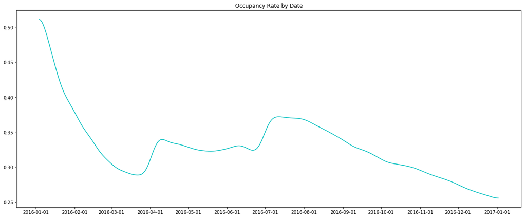

```python
timeplot(ocp, 'occupancy', 'Occupancy Rate by Date')
```

The highest occupancy rate is in January 2016, and decreasing rapidly from 50% to 30% in 2 months. Then, it goes up slightly in the start of April and in the start of July separately. After that, it declines continuously. It seems that spring and summer are the busy season. The best weather in Seattle is from late June to early September. And, in fact, there is a peak during that time. However, it is weird to see the highest occupancy rate is in January 2016. It might be because any festivals. Or did the hotels change their price strategy to become more competitive?

```python
pri_median = df_calendar[['date', 'price']].groupby('date').median()
```

[figure not shown]

```python
timeplot(pri_median, 'price', 'Median Price by Date')
```

[output not shown]

# that's doesn't make sense;

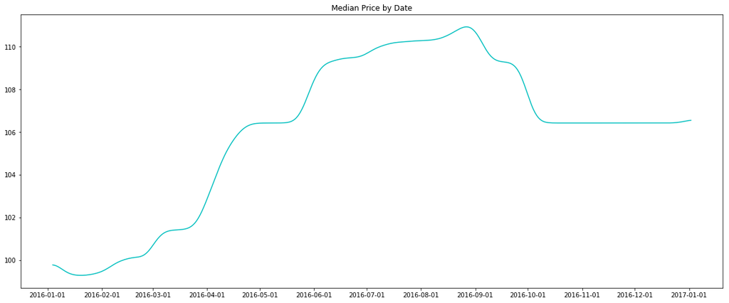

```python
timeplot(pri_median, 'price', 'Median Price by Date')
```

Obviously, the rental price are higher from May to September. In that time, Seattle usually have nice weather. It makes sense that rental price in Rainy Day is cheaper. In addition, the cheapest price is in in January 2016. It could be a reason for high occupancy

### Popular Airbnb Homes

```python
ocp = df_calendar[['listing_id', 'available']].groupby('listing_id').mean()
ocp['occupancy'] = 1 - ocp['available']
ocp.drop(['available'], axis = 1, inplace=True)
ocp['id'] = ocp.index
```

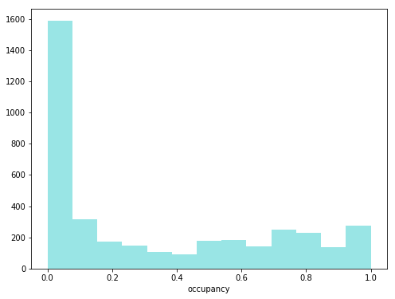

```python
plt.figure(figsize=(8,6))
sns.distplot(ocp['occupancy'], color='c', kde=False)
plt.show()
```

```python
threshold = 0.7
data = pd.merge(ocp, df_listing, how='inner', left_on='id', right_on='id')
```

```python
def comparePlot(feat):
    """
    draw a plot to compare feature of popular and unpopular homes
    """

    plt.figure(figsize=(8,6))

    # if not float, draw bar plot
    if data[feat].dtype != np.float:
        # build a tempary DataFrame for using seaborn easily
        # includes 3 columns: occupancy, popularity and index
        cnt_popular = data[data['occupancy'] >= threshold][feat].value_counts()
        cnt_unpopular = data[data['occupancy'] < threshold][feat].value_counts()
        fre_popular = pd.DataFrame(cnt_popular / sum(cnt_popular))
        fre_popular['popularity'] = 'Popular'
        fre_popular['index'] = fre_popular.index
        fre_unpopular = pd.DataFrame(cnt_unpopular / sum(cnt_unpopular))
        fre_unpopular['popularity'] = 'Unpopular'
        fre_unpopular['index'] = fre_unpopular.index

        plot_data = pd.concat([fre_popular, fre_unpopular], ignore_index=True)
        sns.barplot(x='index', y=feat, hue='popularity', data=plot_data, palette='GnBu')
        plt.xticks(rotation='vertical')
        plt.legend(loc=1)

    # if float, draw kde line
    else:
        sns.kdeplot(data[feat][data['occupancy'] >= threshold], color='m')
        sns.kdeplot(data[feat][data['occupancy'] < threshold], color='c')
        plt.legend(['Popular', 'Unpopular'], loc=1)

    plt.xlabel(feat)
    plt.ylabel('Frequency')

    plt.show()
```

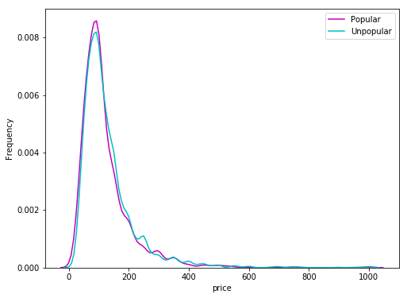

```python
data['price'] = data['price'].map(lambda price: float(price[1:].replace(',', '')), na_action='ignore')
comparePlot('price')
```

**it does make sence , the popular rooms has the cheaper price**

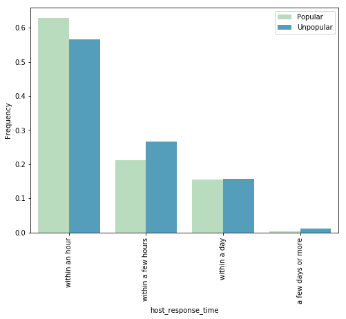

```python
comparePlot('host_response_time')
```

**the host whose is response faster, he has more chance to rent**

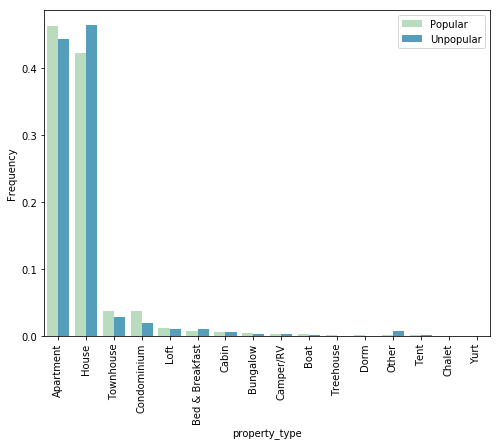

```python
comparePlot('property_type')
```

**the houses are more unpopular.**

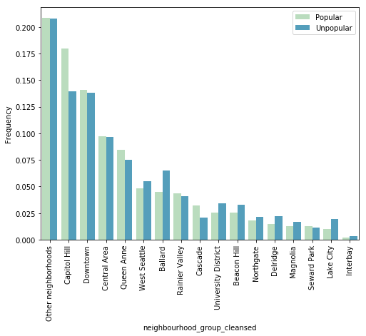

```python
comparePlot('neighbourhood_group_cleansed')
```

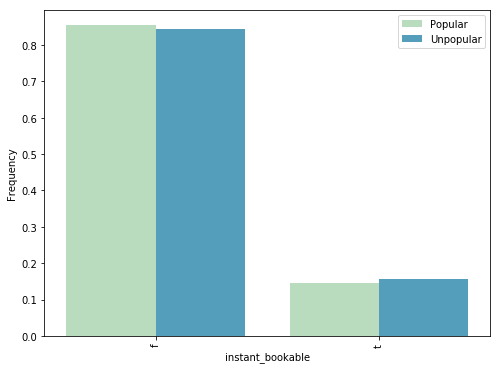

```python
comparePlot('instant_bookable')
```

**it does not matter if you can book the rooms instantly or not**

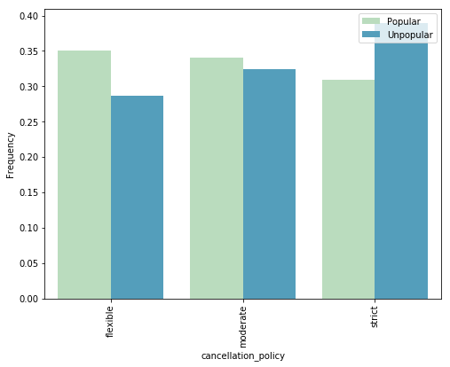

```python
comparePlot('cancellation_policy')
```

**the host who has More flexible cancellation policy,he has more popular.**

### Influencial Features

**Dropping Useless Features**

```python
def drop(data, feat):
    """
    drop feature from data
    """
    new_data = data.drop(feat, axis=1)
    print('Dropping {}...'.format(feat))
    return new_data
```

```python
# drop id
data_clean = drop(df_listing, 'id')
data_clean = drop(data_clean, 'scrape_id')
data_clean = drop(data_clean, 'host_id')
data_clean = drop(data_clean, 'host_verifications')

for feat in data.columns:
    # drop url
    if 'url' in feat:
        data_clean = drop(data_clean, feat)
    # drop name
    if 'name' in feat:
        data_clean = drop(data_clean, feat)
```

```
Dropping id...
Dropping scrape_id...
Dropping host_id...
Dropping host_verifications...
Dropping name...
Dropping host_name...
Dropping jurisdiction_names...
```

```python
#drop_text
data_clean = drop(data_clean, 'summary')
data_clean = drop(data_clean, 'space')
data_clean = drop(data_clean, 'description')
data_clean = drop(data_clean, 'neighborhood_overview')
data_clean = drop(data_clean, 'notes')
data_clean = drop(data_clean, 'transit')
data_clean = drop(data_clean, 'host_about')
```

```
Dropping summary...
Dropping space...
Dropping description...
Dropping neighborhood_overview...
Dropping notes...
Dropping transit...
Dropping host_about...
```

```python
# drop identical features
for feat in data_clean.columns:
    if len(data_clean[feat].value_counts()) <= 1:
        data_clean = drop(data_clean, feat)
```

```
Dropping last_scraped...
Dropping experiences_offered...
Dropping market...
Dropping country_code...
Dropping country...
Dropping has_availability...
Dropping calendar_last_scraped...
Dropping requires_license...
```

```python
# drop identical features
data_clean = drop(data_clean, 'city')
data_clean = drop(data_clean, 'state')
data_clean = drop(data_clean, 'smart_location')
```

```
Dropping city...
Dropping state...
Dropping smart_location...
```

```python
# only need 'neighbourhood_group_cleansed' as feature of home location
data_clean = drop(data_clean, 'street')
data_clean = drop(data_clean, 'neighbourhood')
data_clean = drop(data_clean, 'neighbourhood_cleansed')
data_clean = drop(data_clean, 'zipcode')
data_clean = drop(data_clean, 'latitude')
data_clean = drop(data_clean, 'longitude')
```

```
Dropping street...
Dropping neighbourhood...
Dropping neighbourhood_cleansed...
Dropping zipcode...
Dropping latitude...
Dropping longitude...
```

```python
# for price, only keep price as label
data_clean = drop(data_clean, 'weekly_price')
data_clean = drop(data_clean, 'cleaning_fee')
data_clean = drop(data_clean, 'extra_people')
```

```
Dropping weekly_price...
Dropping cleaning_fee...
Dropping extra_people...
```

```python
# drop all reviews
for feat in data_clean.columns:
    # drop url
    if 'review' in feat:
        data_clean = drop(data_clean, feat)
```

```
Dropping number_of_reviews...
Dropping first_review...
Dropping last_review...
Dropping review_scores_rating...
Dropping review_scores_accuracy...
Dropping review_scores_cleanliness...
Dropping review_scores_checkin...
Dropping review_scores_communication...
Dropping review_scores_location...
Dropping review_scores_value...
Dropping reviews_per_month...
```

```python
# for listing count, only keep the calculated one

data_clean = drop(data_clean, 'host_listings_count')
data_clean = drop(data_clean, 'host_total_listings_count')
```

```
Dropping host_listings_count...
Dropping host_total_listings_count...
```

```python
# keep only anual avaliability
data_clean = drop(data_clean, 'availability_30')
data_clean = drop(data_clean, 'availability_60')
data_clean = drop(data_clean, 'availability_90')
```

```
Dropping availability_30...
Dropping availability_60...
Dropping availability_90...
```

### Encode Features

**Checking for missing data isn't the only way in which you can prepare a dataset for analysis. Since the unsupervised learning techniques to be used will only work on data that is encoded numerically, you need to make a few encoding changes or additional assumptions to be able to make progress. In addition, while almost all of the values in the dataset are encoded using numbers, not all of them represent numeric values.**

**For numeric and interval data, these features can be kept without changes. Most of the variables in the dataset are ordinal in nature. While ordinal values may technically be non-linear in spacing, make the simplifying assumption that the ordinal variables can be treated as being interval in nature (that is, kept without any changes). Special handling may be necessary for the remaining two variable types: categorical, and 'mixed'.**

**i will perform an investigation of the categorical and mixed-type features and make a decision on each of them, whether you will keep, drop, or re-encode each. Then, in the last part, you will create a new data frame with only the selected and engineered columns.**

```python
def oneHot(feat, data):
    """
    encode an categorical data as one-hot
    """
    print('Ecoding {} as one-hot..'.format(feat))
    cur_dummies = pd.get_dummies(data[feat], prefix=feat)
    data.drop(feat, axis=1, inplace=True)
    data = pd.concat([data, cur_dummies], axis=1)
    return data
```

```python
feats = []
conts = []
for feat in data_clean.columns:
    if data_clean[feat].dtype == np.float:
        print('{} is a continous varibale'.format(feat))
        # take a look which columns are float
        conts.append(feat)
    elif len(data_clean[feat].value_counts()) <= 5:
        # for categorical variables with small categories, encode them as one hot
        data_clean = oneHot(feat, data_clean)
    else:
        # if categorical variables have many distinct values, we should be more careful
        feats.append(feat)
```

```
Ecoding host_response_time as one-hot..
host_acceptance_rate is a continous varibale
Ecoding host_is_superhost as one-hot..
Ecoding host_has_profile_pic as one-hot..
Ecoding host_identity_verified as one-hot..
Ecoding is_location_exact as one-hot..
Ecoding room_type as one-hot..
bathrooms is a continous varibale
bedrooms is a continous varibale
beds is a continous varibale
Ecoding bed_type as one-hot..
Ecoding instant_bookable as one-hot..
Ecoding cancellation_policy as one-hot..
Ecoding require_guest_profile_picture as one-hot..
Ecoding require_guest_phone_verification as one-hot..
```

```python
# there are some continouns variables
print(conts)
```

```
['host_acceptance_rate', 'bathrooms', 'bedrooms', 'beds']
```

```python
# there are some variables we should pay more attention on
print(feats)
```

```
['host_since', 'host_location', 'host_response_rate', 'host_neighbourhood', 'neighbourhood_group_cleansed', 'property_type', 'accommodates', 'amenities', 'price', 'guests_included', 'minimum_nights', 'maximum_nights', 'calendar_updated', 'availability_365', 'calculated_host_listings_count']
```

```python
data_clean['host_since'].head()
```

```
0    2011-08-11
1    2013-02-21
2    2014-06-12
3    2013-11-06
4    2011-11-29
Name: host_since, dtype: object
```

```python
data_clean['host_since'] = data_clean['host_since'].map(lambda date: 2015 - int(date[:4]), na_action='ignore')
```

```python
data_clean['host_since'].value_counts()
```

```
 0    981
 1    900
 2    778
 3    539
 4    398
 5    149
 6     64
-1      5
 7      4
Name: host_since, dtype: int64
```

```python
data_clean = oneHot('host_since', data_clean)
```

```
Ecoding host_since as one-hot..
```

```python
data_clean['host_location'].value_counts()
```

```
Seattle, Washington, United States                             3267
US                                                              246
Spokane, Washington, United States                               41
Kent, Washington, United States                                  34
Los Angeles, California, United States                           13
Bellevue, Washington, United States                              12
San Francisco, California, United States                         11
Mercer Island, Washington, United States                         10
Kirkland, Washington, United States                               8
New York, New York, United States                                 6
Sammamish, Washington, United States                              5
Vashon, Washington, United States                                 5
Seattle                                                           5
Shoreline, Washington, United States                              5
Tucson, Arizona, United States                                    4
Portland, Oregon, United States                                   4
Seattle, Washington                                               4
Vancouver, Washington, United States                              4
San Diego, California, United States                              4
Montezuma,Costas Rica  and Seattle Wasington, United States       3
Seattle/San Fransisco/Taipei                                      3
Vancouver, British Columbia, Canada                               3
Blaine, Washington, United States                                 3
San Francisco, California                                         3
Issaquah, Washington, United States                               3
Washington State, United States                                   3
Palm Springs, California, United States                           3
We live in the upper portion of the home                          2
Palo Alto, California, United States                              2
Renton, Washington, United States                                 2
                                                               ...
Santa Monica, California, United States                           1
Gosnold, Massachusetts, United States                             1
Salt Lake City, Utah, United States                               1
California, Maryland, United States                               1
San Jose, California, United States                               1
Kenilworth, Illinois, United States                               1
Greenwood Village, Colorado, United States                        1
Mount Vernon, Washington, United States                           1
Surprise, Arizona, United States                                  1
SG                                                                1
West New York, New Jersey, United States                          1
Luxembourg                                                        1
Oregon                                                            1
Chelan, Washington, United States                                 1
Gig Harbor, Washington, United States                             1
Cambridge, Massachusetts, United States                           1
Arlington, Massachusetts, United States                           1
Winston-Salem, North Carolina, United States                      1
All over the Planet. I'm having a Maui Moment.                    1
Port Orchard, Washington, United States                           1
Woodinville, Washington, United States                            1
Castle Rock, Washington, United States                            1
Lafayette, California, United States                              1
FR                                                                1
Lynnwood, Washington, United States                               1
Calgary, Alberta, Canada                                          1
Hilo, Hawaii, United States                                       1
Santa Fe, New Mexico, United States                               1
Vashon Island, Seattle, WA                                        1
Prescott Valley, Arizona, United States                           1
Name: host_location, Length: 120, dtype: int64
```

```python
data_clean = drop(data_clean, 'host_location')
```

```
Dropping host_location...
```

```python
data_clean['host_neighbourhood'].value_counts()
```

```
Capitol Hill                 705
Belltown                     254
Ballard                      210
Minor                        191
Queen Anne                   189
Fremont                      147
Wallingford                  134
North Beacon Hill            101
Ravenna                      100
Central Business District     93
Stevens                       87
First Hill                    85
Greenwood                     80
University District           80
Lower Queen Anne              75
Columbia City                 61
Green Lake                    55
North Admiral                 53
Magnolia                      53
Phinney Ridge                 52
Atlantic                      49
Leschi                        46
Mount Baker                   44
Eastlake                      42
Maple Leaf                    40
Madrona                       40
The Junction                  39
Roosevelt                     32
Pike Place Market             31
Genesee                       30
                            ...
South Park                     6
Brighton                       5
Broadway                       5
Interbay                       4
Industrial District            3
Arbor Heights                  3
Kaanapali                      2
Fenway/Kenmore                 2
Jamaica Plain                  2
Mission District               2
Central San Pedro              1
East Village                   1
Waianae Coast                  1
North Hollywood                1
Roxhill                        1
Santa Monica                   1
Hell's Kitchen                 1
North College Park             1
Downtown Toronto               1
Northwest District             1
Pinehurst                      1
Beverly Hills                  1
Kauaʻi                         1
South Beacon Hill              1
Forestland                     1
Baldwin Hills                  1
Long Beach                     1
Clairemont Mesa East           1
Huntington Beach               1
Manhattan Beach                1
Name: host_neighbourhood, Length: 102, dtype: int64
```

```python
# so many different neighbourhood here, drop it
data_clean = drop(data_clean, 'host_neighbourhood')
```

```
Dropping host_neighbourhood...
```

```python
data_clean['neighbourhood_group_cleansed'].value_counts()
```

```
Other neighborhoods    794
Capitol Hill           567
Downtown               530
Central Area           369
Queen Anne             295
Ballard                230
West Seattle           203
Rainier Valley         159
University District    122
Beacon Hill            118
Cascade                 89
Northgate               80
Delridge                79
Lake City               67
Magnolia                61
Seward Park             44
Interbay                11
Name: neighbourhood_group_cleansed, dtype: int64
```

```python
data_clean = oneHot('neighbourhood_group_cleansed', data_clean)
```

```
Ecoding neighbourhood_group_cleansed as one-hot..
```

```python
data_clean['property_type'].value_counts()
```

```
House              1734
Apartment          1708
Townhouse           118
Condominium          91
Loft                 40
Bed & Breakfast      37
Other                22
Cabin                21
Camper/RV            13
Bungalow             13
Boat                  8
Tent                  5
Treehouse             3
Chalet                2
Dorm                  2
Yurt                  1
Name: property_type, dtype: int64
```

```python
data_clean = oneHot('property_type', data_clean)
```

```
Ecoding property_type as one-hot..
```

```python
data_clean['calendar_updated'].value_counts()
```

```
today            706
2 weeks ago      347
3 weeks ago      300
2 months ago     281
a week ago       248
yesterday        231
3 months ago     218
4 weeks ago      213
3 days ago       162
5 weeks ago      156
4 days ago       145
4 months ago     133
5 days ago       132
6 weeks ago      118
2 days ago        96
```

[output cut: 20 more lines]

```python
data_clean = drop(data_clean, 'calendar_updated')
```

```
Dropping calendar_updated...
```

```python
data_clean['amenities'].head()
```

```
0    {TV,"Cable TV",Internet,"Wireless Internet","A...
1    {TV,Internet,"Wireless Internet",Kitchen,"Free...
2    {TV,"Cable TV",Internet,"Wireless Internet","A...
3    {Internet,"Wireless Internet",Kitchen,"Indoor ...
4    {TV,"Cable TV",Internet,"Wireless Internet",Ki...
Name: amenities, dtype: object
```

```python
# to see how many different amenities there are
amenities = set()
for a in data_clean['amenities']:
    amenities |= set(a)
print(len(a))
print(a)
```

```
314
{TV,"Cable TV",Internet,"Wireless Internet",Kitchen,"Free Parking on Premises","Pets live on this property",Dog(s),"Elevator in Building","Hot Tub","Indoor Fireplace","Buzzer/Wireless Intercom",Heating,"Family/Kid Friendly",Washer,Dryer,"Smoke Detector",Essentials,Shampoo,Hangers,Iron,"Laptop Friend…
```

```python
# create new bainary columns if one amentity exist
for a in amenities:
    data_clean[a] = data_clean['amenities'].apply(lambda amenities: 1 if a in amenities else 0)
# do not forget to drop orignal columns
data_clean = drop(data_clean, 'amenities')
```

```
Dropping amenities...
```

## Feature Transformation

### Step 1: Apply Feature Scaling

Before we apply dimensionality reduction techniques to the data, we need to perform feature scaling so that the principal component vectors are not influenced by the natural differences in scale for features. you'll want to keep an eye on the [API reference page for sklearn](http://scikit-learn.org/stable/modules/classes.html) to help you navigate to all of the classes and functions that you'll need. In this substep, you'll need to check the following:

- sklearn requires that data not have missing values in order for its estimators to work properly. So, before applying the scaler to your data, make sure that you've cleaned the DataFrame of the remaining missing values. This can be as simple as just removing all data points with missing data, or applying an [Imputer](http://scikit-learn.org/stable/modules/generated/sklearn.preprocessing.Imputer.html) to replace all missing values. You might also try a more complicated procedure where you temporarily remove missing values in order to compute the scaling parameters before re-introducing those missing values and applying imputation. Think about how much missing data you have and what possible effects each approach might have on your analysis, and justify your decision in the discussion section below.
- For the actual scaling function, a [StandardScaler](http://scikit-learn.org/stable/modules/generated/sklearn.preprocessing.StandardScaler.html) instance is suggested, scaling each feature to mean 0 and standard deviation 1.
- For these classes, you can make use of the `.fit_transform()` method to both fit a procedure to the data as well as apply the transformation to the data at the same time. Don't forget to keep the fit sklearn objects handy.

```python
# Apply feature scaling to the general population demographics data.
#StandardScaler is to scale data so that it has  mean 0 and variance 1.

scaler = p.StandardScaler()
columns = data_clean.columns
data_clean = scaler.fit_transform(data_clean)
data_clean = pd.DataFrame(data_clean)
data_clean.columns = columns
```

```python
data_clean.head()
```

|  | host_response_rate | host_acceptance_rate | accommodates | bathrooms | bedrooms | beds | price | guests_included | minimum_nights | maximum_nights | ... | h | g | p | W |  | t | i | y | o | a |
| --- | --- | --- | --- | --- | --- | --- | --- | --- | --- | --- | --- | --- | --- | --- | --- | --- | --- | --- | --- | --- | --- |
| 0 | 0.036982 | 2.029560e-02 | 0.329029 | -0.440484 | -0.348649 | -0.645546 | -0.476252 | 0.249756 | -0.083987 | -0.246795 | ... | 0.136662 | 0.151802 | -2.132937 | 0.139616 | 0.114021 | 0.10921 | 0.110432 | 0.286705 | 0.158876 | 0.116356 |
| 1 | 0.216167 | 2.029560e-02 | 0.329029 | -0.440484 | -0.348649 | -0.645546 | 0.244063 | -0.513098 | -0.022651 | -0.410158 | ... | 0.136662 | 0.151802 | -2.132937 | 0.139616 | 0.114021 | 0.10921 | 0.110432 | 0.286705 | 0.158876 | 0.116356 |
| 2 | -2.561195 | 2.029560e-02 | 3.869138 | 5.501253 | 4.183494 | 4.621394 | 9.386533 | 6.352583 | 0.100020 | -0.445801 | ... | 0.136662 | 0.151802 | 0.468837 | 0.139616 | 0.114021 | 0.10921 | 0.110432 | 0.286705 | 0.158876 | 0.116356 |
| 3 | 0.395351 | 8.782325e-15 | -0.176701 | -0.440484 | -1.481685 | 0.232277 | -0.310026 | -0.513098 | -0.083987 | 0.204680 | ... | 0.136662 | 0.151802 | 0.468837 | 0.139616 | 0.114021 | 0.10921 | 0.110432 | 0.286705 | 0.158876 | 0.116356 |
| 4 | 0.395351 | 8.782325e-15 | 1.340489 | 1.257155 | 1.917422 | 1.110101 | 3.568598 | 3.301169 | -0.083987 | 0.204680 | ... | 0.136662 | 0.151802 | 0.468837 | 0.139616 | 0.114021 | 0.10921 | 0.110432 | 0.286705 | 0.158876 | 0.116356 |

5 rows × 136 columns

### Step 2: Perform Dimensionality Reduction

On your scaled data, you are now ready to apply dimensionality reduction techniques.

- Use sklearn's [PCA](http://scikit-learn.org/stable/modules/generated/sklearn.decomposition.PCA.html) class to apply principal component analysis on the data, thus finding the vectors of maximal variance in the data. To start, you should not set any parameters (so all components are computed) or set a number of components that is at least half the number of features (so there's enough features to see the general trend in variability).
- Check out the ratio of variance explained by each principal component as well as the cumulative variance explained. Try plotting the cumulative or sequential values using matplotlib's [`plot()`](https://matplotlib.org/api/_as_gen/matplotlib.pyplot.plot.html) function. Based on what you find, select a value for the number of transformed features you'll retain for the clustering part of the project.
- Once you've made a choice for the number of components to keep, make sure you re-fit a PCA instance to perform the decided-on transformation.

```python
def scree_plot(pca):
    '''
    Creates a scree plot associated with the principal components

    INPUT: pca - the result of instantian of PCA in scikit learn

    OUTPUT:
            None
    '''
    num_components = len(pca.explained_variance_ratio_)
    ind = np.arange(num_components)
    vals = pca.explained_variance_ratio_

    plt.figure(figsize=(10, 6))
    ax = plt.subplot(111)
    cumvals = np.cumsum(vals)
    ax.bar(ind, vals)
    ax.plot(ind, cumvals)

    ax.xaxis.set_tick_params(width=0)
    ax.yaxis.set_tick_params(width=2, length=12)

    ax.set_xlabel("Principal Component")
    ax.set_ylabel("Variance Explained (%)")
    plt.title('Explained Variance Per Principal Component')
```

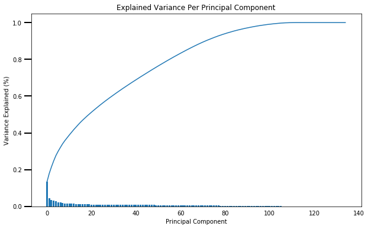

```python
# Re-apply PCA to the data while selecting for number of components to retain.
pca = PCA(n_components=135)  #n_components - int - the number of principal components to create data - the data you would like to transform
data_clean_pca = pca.fit_transform(data_clean) #it fits the pca

scree_plot(pca)
#OUTPUT: pca - the pca object created after fitting the data 'data_clean_pca - the transformed few_missing matrix with new number of components
```

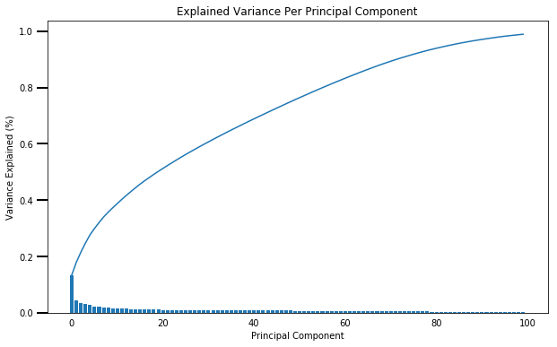

```python
# Re-apply PCA to the data while selecting for number of components to retain.
pca = PCA(n_components=100)  #n_components - int - the number of principal components to create data - the data you would like to transform
data_clean_pca = pca.fit_transform(data_clean) #it fits the pca

#OUTPUT: pca - the pca object created after fitting the data 'data_clean_pca - the transformed few_missing matrix with new number of components

scree_plot(pca)
```

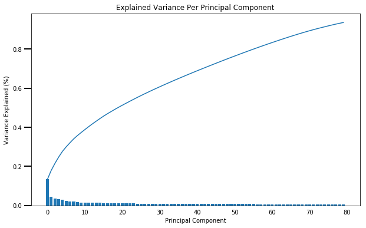

```python
# Re-apply PCA to the data while selecting for number of components to retain.
pca = PCA(n_components=80)  #n_components - int - the number of principal components to create data - the data you would like to transform
data_clean_pca = pca.fit_transform(data_clean) #it fits the pca

#OUTPUT: pca - the pca object created after fitting the data 'data_clean_pca - the transformed few_missing matrix with new number of components

scree_plot(pca)
```

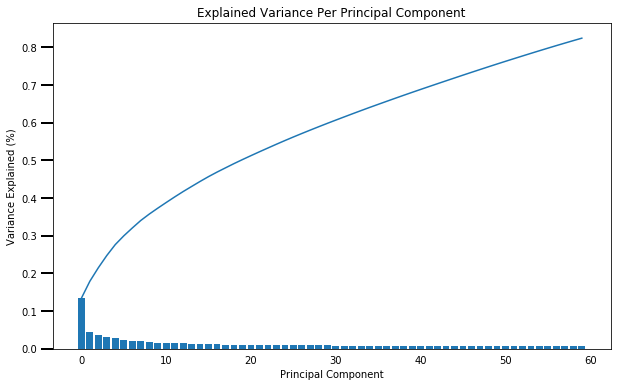

```python
# Re-apply PCA to the data while selecting for number of components to retain.
pca = PCA(n_components=60)  #n_components - int - the number of principal components to create data - the data you would like to transform
data_clean_pca = pca.fit_transform(data_clean) #it fits the pca

#OUTPUT: pca - the pca object created after fitting the data 'data_clean_pca - the transformed few_missing matrix with new number of components

scree_plot(pca)
```

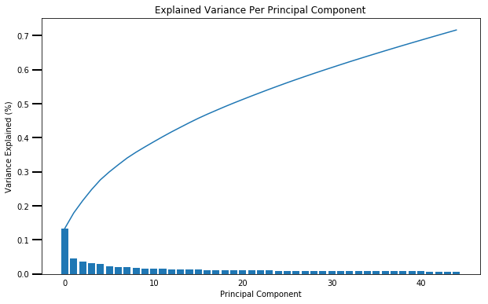

```python
# Re-apply PCA to the data while selecting for number of components to retain.
pca = PCA(n_components=45)  #n_components - int - the number of principal components to create data - the data you would like to transform
data_clean_pca = pca.fit_transform(data_clean) #it fits the pca

#OUTPUT: pca - the pca object created after fitting the data 'data_clean_pca - the transformed few_missing matrix with new number of components

scree_plot(pca)
```

**principle component analysis "pca" allows us to retain the informative parts of our data but with less of it**

### Step 3: Interpret Principal Components

Now that we have our transformed principal components, it's a nice idea to check out the weight of each variable on the first few components to see if they can be interpreted in some fashion.

As a reminder, each principal component is a unit vector that points in the direction of highest variance (after accounting for the variance captured by earlier principal components). The further a weight is from zero, the more the principal component is in the direction of the corresponding feature. If two features have large weights of the same sign (both positive or both negative), then increases in one tend expect to be associated with increases in the other. To contrast, features with different signs can be expected to show a negative correlation: increases in one variable should result in a decrease in the other.

- To investigate the features, you should map each weight to their corresponding feature name, then sort the features according to weight. The most interesting features for each principal component, then, will be those at the beginning and end of the sorted list. Use the data dictionary document to help you understand these most prominent features, their relationships, and what a positive or negative value on the principal component might indicate.
- You should investigate and interpret feature associations from the first three principal components in this substep. To help facilitate this, you should write a function that you can call at any time to print the sorted list of feature weights, for the *i*-th principal component.

```python
def pca_weights(pca, i):
    weight_map = {}
    for counter, feature in enumerate(data_clean.columns):
        weight_map[feature] = pca.components_[i][counter]

    sorted_weights = sorted(weight_map.items(), key=operator.itemgetter(1), reverse=True)

    return sorted_weights
```

```python
# Map weights for the third principal component to corresponding feature names
# and then print the linked values, sorted by weight.

weights = pca_weights(pca,1)

# Prints the nicely formatted dictionary
pprint.pprint(weights)
```

```
[('accommodates', 0.2588310183604104),
 ('beds', 0.22348269080444993),
 ('price', 0.22214863701391982),
 ('room_type_Entire home/apt', 0.218753868576406),
 ('bedrooms', 0.1875611050140878),
 ('cancellation_policy_strict', 0.17040524724406464),
 ('/', 0.16863716570069012),
 ('4', 0.16657302605868973),
 ('2', 0.16657302605868973),
 ('-', 0.16657302605868973),
 ('require_guest_phone_verification_t', 0.15911872853289893),
 ('V', 0.15911763596456954),
 ('require_guest_profile_picture_t', 0.1573970026016092),
 ('T', 0.156481173593262),
 ('guests_included', 0.1562132230228055),
 ('neighbourhood_group_cleansed_Downtown', 0.1515372039016119),
 ('b', 0.14894067682486128),
 ('bathrooms', 0.1473674117953474),
 ('C', 0.1407003109112234),
 ('G', 0.138833016930857),
 ('u', 0.12878722111911692),
 ('M', 0.12791772687125108),
 ('L', 0.12114935208693764),
 ('x', 0.114845784775643),
 ('A', 0.10672572899308397),
 ('z', 0.10304697672193726),
 ('d', 0.09613461868414784),
 ('bed_type_Real Bed', 0.08922219004698044),
 ('f', 0.08602803624676487),
 ('B', 0.08245504813825832),
 ('host_identity_verified_t', 0.05505881988271312),
 ('F', 0.05262159963328991),
 ('property_type_Apartment', 0.05168366337997802),
 ('y', 0.05139561549669266),
 ('S', 0.04835190149461036),
 ('host_since_2', 0.04802023355143345),
 ('instant_bookable_t', 0.04533617529765774),
 ('host_is_superhost_t', 0.04360031194710712),
 ('property_type_Condominium', 0.04181526011368608),
 ('E', 0.041092932671561895),
```

[output cut: 81 more lines]

```
 ('(', -0.07421552151607111),
 (')', -0.07421552151607111),
 ('s', -0.079415703161467),
 ('"', -0.08001538596541594),
 (' ', -0.08001538596541594),
 ('r', -0.08056611276362105),
 ('i', -0.08241169841703218),
 (',', -0.08322158171231832),
 ('n', -0.08407994896858363),
 ('e', -0.08407994896858363),
 ('t', -0.08407994896858363),
 ('cancellation_policy_flexible', -0.1216624247244014),
 ('require_guest_profile_picture_f', -0.1573970026016092),
 ('require_guest_phone_verification_f', -0.15911872853289893),
 ('room_type_Private room', -0.20002388315004455)]
```

```python
weights = pca_weights(pca,2)

# Prints the nicely formatted dictionary
pprint.pprint(weights)
```

```
[('bedrooms', 0.2991183837753057),
 ('property_type_House', 0.2585982029226685),
 ('beds', 0.2552633968855702),
 ('accommodates', 0.24892291267504954),
 ('bathrooms', 0.2192189112170306),
 ('guests_included', 0.19405749668655406),
 ('require_guest_profile_picture_f', 0.19036093916803853),
 ('require_guest_phone_verification_f', 0.18612346069203625),
 ('price', 0.183904228709611),
 ('P', 0.15766487038968932),
 ('neighbourhood_group_cleansed_Other neighborhoods', 0.09546916253136808),
 ('F', 0.09390435332200832),
 ('w', 0.06256612338496227),
 ('neighbourhood_group_cleansed_Central Area', 0.061799067240606124),
 ('(', 0.061734009382917676),
 (')', 0.061734009382917676),
 ('neighbourhood_group_cleansed_West Seattle', 0.061280368779983885),
 ('bed_type_Real Bed', 0.053665614559065315),
 ('neighbourhood_group_cleansed_Ballard', 0.04369793602425306),
 ('room_type_Entire home/apt', 0.0435719141405105),
 ('/', 0.043505616539135566),
 ('host_identity_verified_f', 0.04194816600704739),
 ('is_location_exact_t', 0.04174893753637647),
 ('V', 0.04035096724528401),
 ('T', 0.039600130874962336),
 ('host_since_1', 0.03926757979981537),
 ('neighbourhood_group_cleansed_Magnolia', 0.03897632510629724),
 ('instant_bookable_f', 0.03793054669823213),
 ('k', 0.036887281217337704),
 ('neighbourhood_group_cleansed_Rainier Valley', 0.03644804307865841),
 ('host_response_time_within a few hours', 0.03533333590246462),
 ('property_type_Townhouse', 0.03335845594651),
 ('b', 0.03091455008392891),
 ('y', 0.028369680374312742),
 ('x', 0.028325157264940472),
 ('O', 0.027994412604673204),
 ('neighbourhood_group_cleansed_Seward Park', 0.026952018902152697),
 ('cancellation_policy_moderate', 0.02545200692900517),
 ('C', 0.02414928481332788),
 ('d', 0.022584820005669696),
```

[output cut: 81 more lines]

```
 ('room_type_Shared room', -0.05298902375752625),
 ('L', -0.08301166017080693),
 ('calculated_host_listings_count', -0.08823613647425703),
 ('u', -0.08838897032937473),
 ('4', -0.10861180299528805),
 ('2', -0.10861180299528805),
 ('-', -0.10861180299528805),
 ('v', -0.1250078432581299),
 ('G', -0.185411948466325),
 ('require_guest_phone_verification_t', -0.18612346069203625),
 ('require_guest_profile_picture_t', -0.19036093916803853),
 ('z', -0.20756057900837194),
 ('neighbourhood_group_cleansed_Downtown', -0.2290696234717766),
 ('property_type_Apartment', -0.24655964762934776),
 ('B', -0.2582570724299552)]
```

```python
weights = pca_weights(pca,3)

# Prints the nicely formatted dictionary
pprint.pprint(weights)
```

```
[('require_guest_phone_verification_t', 0.26799827465809817),
 ('require_guest_profile_picture_t', 0.26376390885564277),
 ('calculated_host_listings_count', 0.14327611890449002),
 ('host_since_4', 0.1332821640300596),
 ('cancellation_policy_strict', 0.12890596122328785),
 ('instant_bookable_f', 0.1127855990867629),
 ('bedrooms', 0.10581121014847393),
 ('host_since_3', 0.10466584688347165),
 ('price', 0.10287182175082818),
 ('accommodates', 0.10113381210054972),
 ('beds', 0.09950005135374743),
 ('host_response_time_within a few hours', 0.09534889632509091),
 ('host_response_time_within a day', 0.0908444822273267),
 ('bathrooms', 0.08031610161094413),
 ('host_since_5', 0.0652478306396216),
 ('n', 0.06242131658572992),
 ('e', 0.06242131658572992),
 ('t', 0.06242131658572992),
 (',', 0.06211372344253543),
 ('s', 0.06134387873092026),
 ('i', 0.060778113112211485),
 ('r', 0.06050936886779266),
 ('"', 0.05986932403607668),
 (' ', 0.05986932403607668),
 ('host_identity_verified_t', 0.05899911112511145),
 ('l', 0.05800018325131503),
 ('W', 0.057114187404067054),
 ('availability_365', 0.05528278635324583),
 ('a', 0.05124274510041136),
 ('I', 0.05119229827533031),
 ('property_type_House', 0.04680378340491846),
 ('guests_included', 0.046752664335746305),
 ('room_type_Entire home/apt', 0.04564807475744757),
 ('host_since_6', 0.04367976878477824),
 ('bed_type_Real Bed', 0.039055881001435415),
 ('h', 0.03409611467707663),
 ('is_location_exact_f', 0.028238159338669733),
 ('property_type_Boat', 0.02763759762277993),
 ('g', 0.025587918273207288),
 ('neighbourhood_group_cleansed_University District', 0.02324629632326772),
```

[output cut: 81 more lines]

```
 ('p', -0.11812696342156491),
 ('S', -0.122931538742714),
 ('b', -0.13404072213857332),
 ('host_since_0', -0.13854421638643172),
 ('u', -0.14767628123277154),
 ('host_response_time_within an hour', -0.15436577878286895),
 ('C', -0.15485631191573992),
 ('x', -0.1688959341511569),
 ('M', -0.17004342482185422),
 ('L', -0.20479445501475174),
 ('4', -0.22008348826172852),
 ('2', -0.22008348826172852),
 ('-', -0.22008348826172852),
 ('require_guest_profile_picture_f', -0.26376390885564277),
 ('require_guest_phone_verification_f', -0.26799827465809817)]
```

We can interpret some relationships between negative and positive weights and positive values together or negative values together.